# Normalized Prediction Distribution Errors

Mutaz M. Jaber

September 10, 2021

Normalized prediction distribution errors (npde) is an evaluation metric used in nonlinear mixed-effect approach (NLME). This metric is a nonparametric version of population weighted residual calculation.

## 0.1 General notation

Let $i$ denote the $i^{th}$ individual and $j$ is the $j^{th}$ measurment point in an individual. $n_{tot}$ is the total observations in dataset.

$$n_{tot} = \sum_{1}^i n_{i}$$

Let $Y_i$ be the observation vector for subject i, and $f(.)$ is the PK model, then for the observation $y_{ij}$:

$$y_{ij} = f(t_{ij}, \theta_i) + \epsilon_{ij}$$

Where $\theta_i$ is vector of individual PK parameters, that we assumed it is log-normally distributed

$$\theta_i = h(\mu) e^{\eta_i}$$

Where $\mu$ is the population value, and $\eta_i$ is the vector of random effects, and usually we assume that $\eta_i$ are normally distributed $\eta_i \sim \mathcal{N}(0, \omega^2)$

> Reminder:

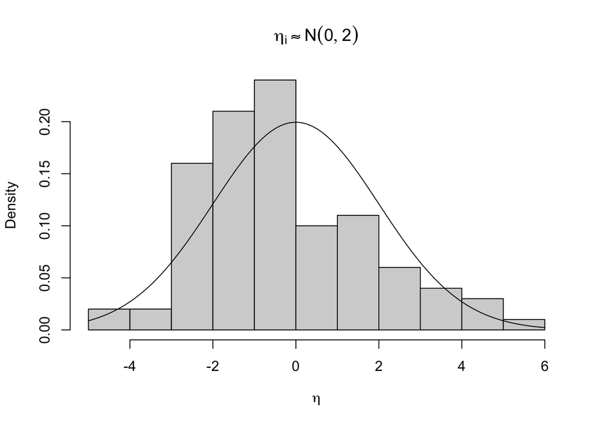

```r
set.seed(1234)
x <- rnorm(100,0, 2)
hist(x, freq=F, xlab=expression(eta), main=expression(eta[i] %~~% N(0, 2)))
curve(dnorm(x, 0, 2),ylab='PDF',  add = TRUE)
```

## 0.2 Predictive Distribution

Taking into consideration that population model $f$ and population parameters $\{\mu, diag(\Omega), \sigma\}$ are given and they define the null model ($H_0$). We can define the predictive distribution ($pd_i$) for the $i^{th}$ subject as:

$$p_i = \int p(y|\theta_i)p(\theta_i)d\theta_i$$

Where $p(y|\theta_i)$ is normally distributed with mean $f(t_{ij}, \theta_i)$ and variance of $\Sigma_i(\theta_i) = diag(\sigma^2h(t_{ij}, \theta_i)$. Since we almost deal with nonlinear systems, there is no analytical expression for $p_i(y)$. Thus, we approximate the distribution using discrete distribution using stochastic simulation MCMC.

$$p_i(y) = \frac{1}{K} \sum_{k=1}^K p(y|\theta_k) = \frac{1}{K} \sum_{k=1}^K \phi(y; f(t_{ij}, \theta_k), \Sigma_i(\theta_k))$$

## 0.3 Prediction Discrepancy

Prediction discrepancy is a method uses stochastic MCMC simulation to generate prediction distribution for each observation. If the model and population parameters are correct, its expected that prediction discrepancy follows a uniform distribution: $pd_i \sim U(0,1)$.

Let $F_{ij}$ be the prediction [distribution function](https://en.wikipedia.org/wiki/Cumulative_distribution_function) of the observation $y_{ij}$ for the $i^{th}$ under the estimated model $M$. We can calculate prediction discrepancy $pd_{ij}$ as the value of $F_{ij}$ at observation $y_{ij}$.

We can simulate $K$ datasets and let $Y^{sim(k)}_i$ denotes the vector of simulated observations for the $i^{th}$ subject in the $k^{th}$ dataset. $pd_i$ is computed as the percentile of $y_{ij}$ based on the theoritcal distribution of $y^{sim(k)}_{ij}$

$$pd_{ij} = F_{ij}(y_{ij}) \approx \frac{1}{K} \sum \delta_{ijk}$$

Where $\delta_{ijk}$ is an indicator function

$$\delta_{ijk} = \begin{cases} 1 & y_{ij}^{sim(k)} < y_{ij} \\ 0 & o.w. \end{cases}$$

However, as we mentioned the distribution of $pd$ is uniform but that the case of one observation per indiviudal without taken into consideration with-subject correlation of multiple observation.

To overcome this issue, a decorrelation step has been proposed

$$pde_{ij} = F^*_{ij}(y^*_{ij}) \approx \frac{1}{K} \sum \delta^*_{ijk}$$

## 0.4 Computation of NPDE

Applying the inverse normal distribution function to $pde_{ij}$ we can obtain normalized prediction distribution error ($npde_{ij}$):

$$npde_{ij} = \phi^{-1}(pde_{ij})$$

With that, if $H_0$ is true, them NPDE will follow a standard normal distribution $npde \sim \mathcal{N}(0, 1)$

## 0.5 NONMEM example

Lets go back to PK hello world;IV-bolus one-compartment model with linear elimination. The implementation is simple in NONMEM, few parameters are added to `$TABLE` block for postprocessing

```
$TABLE ... NPDE NPD ESAMPLE=n
```

The full model:

```
$PROB base
; Drug X; one compartment
; estimat
$INPUT ID TIME AMT DROP DV MDV NUM
$DATA ../../../data/dat1.csv ignore=@

$SUBR ADVAN1 TRANS2
$EST MET=1 PRINT=5 NOABORT INTER

$PK
    TVCL = THETA(1)
    TVV  = THETA(2)

    CL  = TVCL * EXP(ETA(1))
    V   = TVV * EXP(ETA(2))

    S1 = V

$ERROR

IPRED = F
Y  = IPRED * (1 + ERR(1))

$THETA
(0, 5) ; CL
(0, 20) ; V

$OMEGA
0.1
0.1

$SIGMA 0.01
$COVR
$TAB ID NUM TIME AMT DV MDV IPRED PRED CWRES NPDE NPD ESAMPLE=10000 NOPRINT NOAPPEND ONEHEADER FILE=r2.tab
```

Where `ESAMPLE` is the $K$ simulated datasets using MCMC. The default value is 300.

We can plot the data for correlated NPDE and decorrelated one

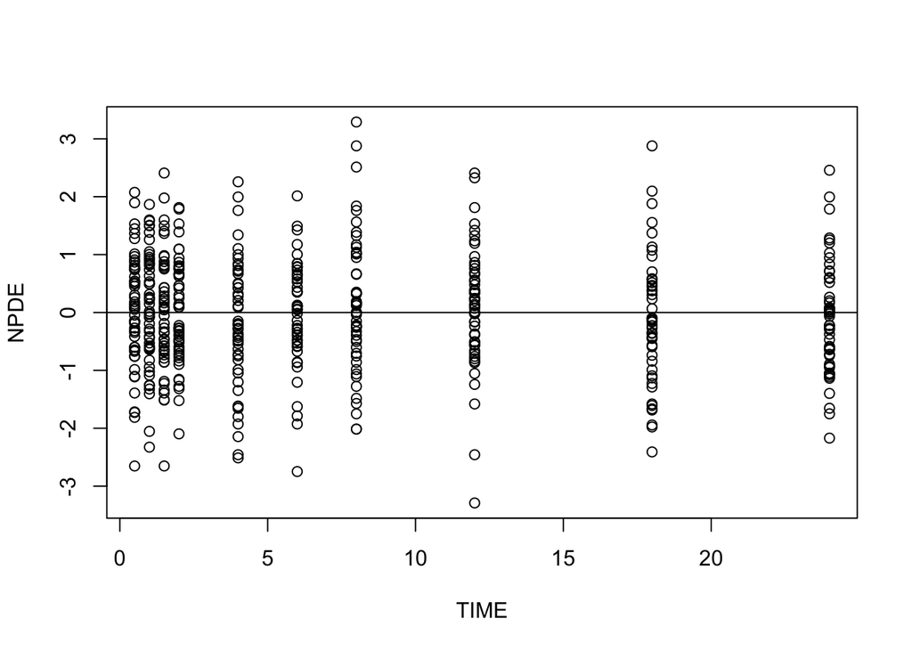

```r
dat <- read.table('src/r1.tab', skip=1, header=TRUE)
dat <- dat[dat$CWRES!=0, ]
with(dat, plot(TIME, NPDE))
abline(h=0)
```

Now with population prediction

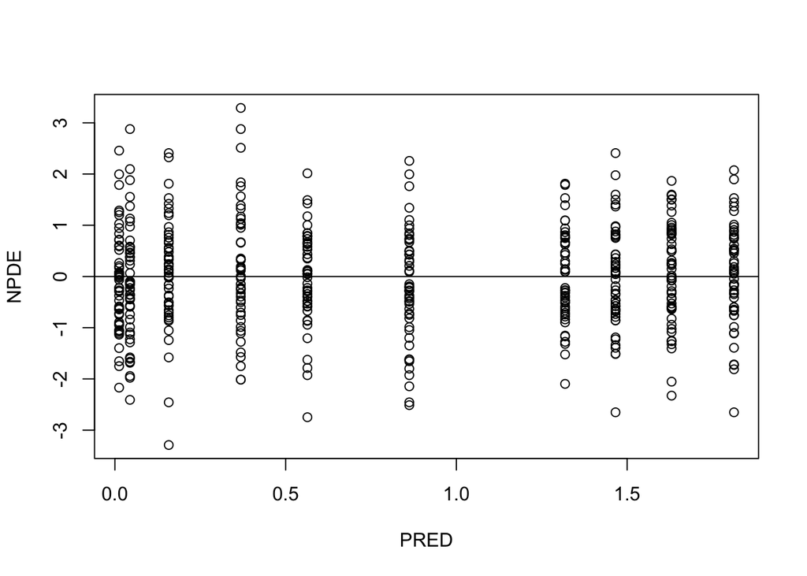

```r
with(dat, plot(PRED, NPDE))
abline(h=0)
```

Same with correlated normalized prediction

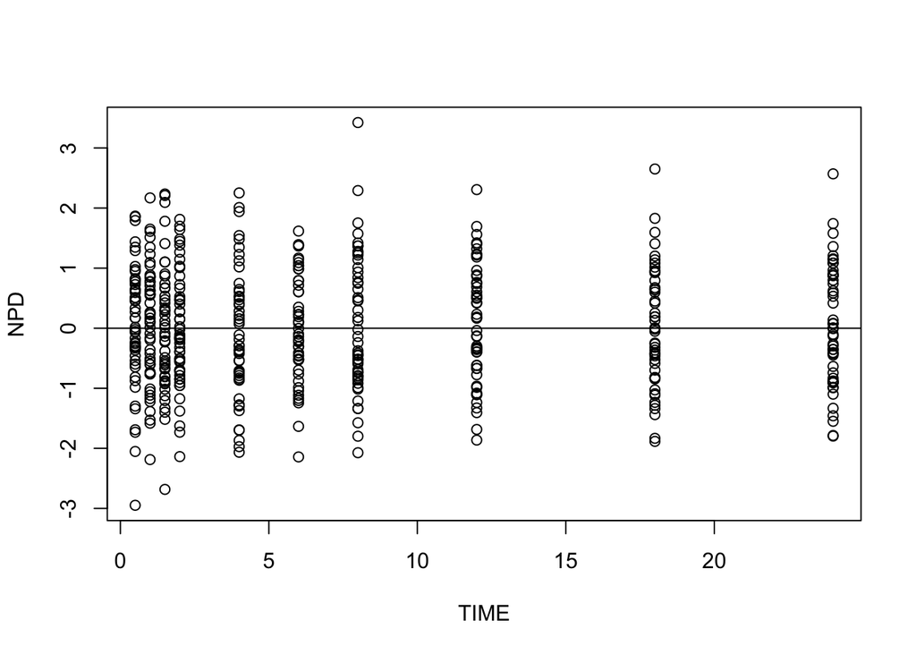

```r
with(dat, plot(TIME, NPD))
abline(h=0)
```

And again with population prediction

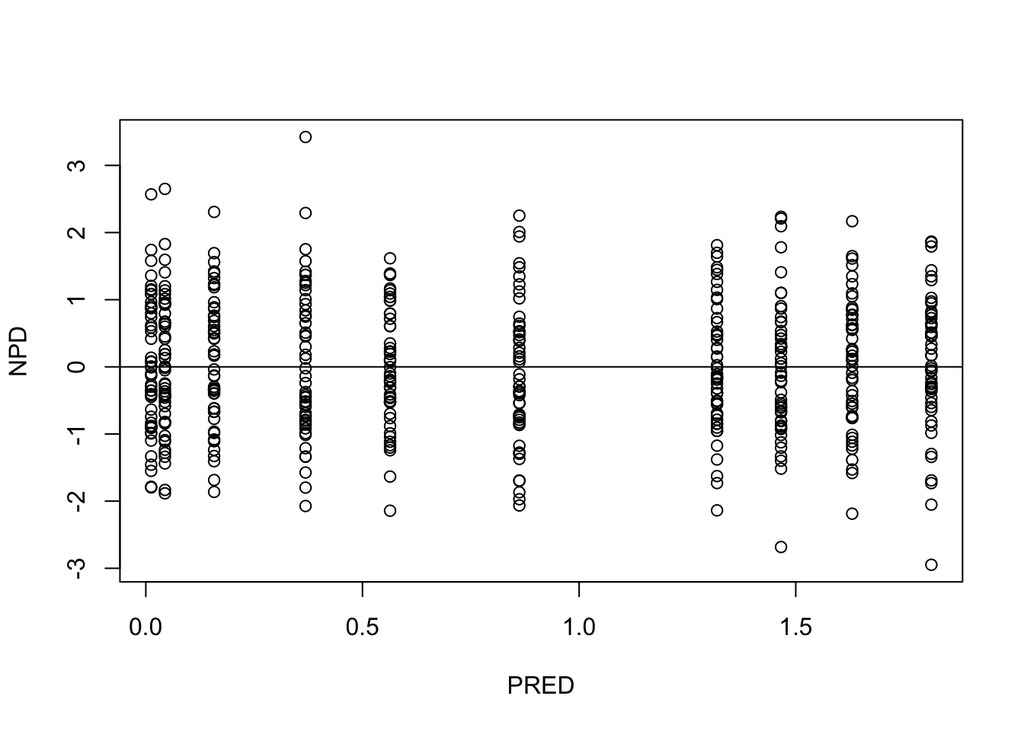

```r
with(dat, plot(PRED, NPD))
abline(h=0)
```

References:

- Computing normalised prediction distribution errors to evaluate nonlinear mixed-effect models: The npde add-on package for R [https://pubmed.ncbi.nlm.nih.gov/18215437/]
- NONMEM VIII User guide